# project

Parthsarthy Nandi

2023-01-28

*Fertility Dataset*

*About the Data - Data was collect from 100 participants whose seminal composition was examined for the prediction of fertility among males.* *10 attributes where considered for that purpose, each having effect on the Diagnosis.*

```
Attributes are:
1. Season in which the analysis is performed
  a. Winter - -1
  b. Spring - -0.33
  c. Summer - 0.33
  d. Fall - 1
2. Age at the time of analysis 18-36 -> (0,1)
3. Childish diseases (ie , chicken pox, measles, mumps, polio) Yes or No -> (0,1)
4. Accident or serious trauma 1) yes, 2) no -> (0, 1)
5. Surgical intervention 1) yes, 2) no. (0, 1)
6. High fevers in the last year 1) less than three months ago, 2) more than three months ago, 3) no. (-1, 0, 1)
7. Frequency of alcohol consumption 1) several times a day, 2) every day, 3) several times a week, 4) once a week, 5) hardly ever or never (0, 1)
8. Smoking habit 1) never, 2) occasional 3) daily. (-1, 0, 1)
9. Number of hours spent sitting per day ene-16 (0, 1)
10. Output: Diagnosis normal (N), altered (O)

Initially the data was in a .txt format which was converted to .csv with the help of Excel and the columns were named.
```

*Load the Data into the environment.*

```r
dataproj <- read.csv("fertility.csv")
head(dataproj, 10)
```

```
##    Season  Age Childish.disease Trauma Surgical.Intervetion
## 1   -0.33 0.69                0      1                    1
## 2   -0.33 0.94                1      0                    1
## 3   -0.33 0.50                1      0                    0
## 4   -0.33 0.75                0      1                    1
## 5   -0.33 0.67                1      1                    0
## 6   -0.33 0.67                1      0                    1
## 7   -0.33 0.67                0      0                    0
## 8   -0.33 1.00                1      1                    1
## 9    1.00 0.64                0      0                    1
## 10   1.00 0.61                1      0                    0
##    High.Fevers.in.Last.year Alcohol.Consumption Smoking.Habit
## 1                         0                 0.8             0
## 2                         0                 0.8             1
## 3                         0                 1.0            -1
```

[output cut: 18 more lines]

```
Checking the data for NA's and other stats.
```

```r
library("dplyr")
summary(dataproj)
```

```
##      Season             Age        Childish.disease     Trauma
##  Min.   :-1.0000   Min.   :0.500   Min.   :0.00     Min.   :0.00
##  1st Qu.:-1.0000   1st Qu.:0.560   1st Qu.:1.00     1st Qu.:0.00
##  Median :-0.3300   Median :0.670   Median :1.00     Median :0.00
##  Mean   :-0.0789   Mean   :0.669   Mean   :0.87     Mean   :0.44
##  3rd Qu.: 1.0000   3rd Qu.:0.750   3rd Qu.:1.00     3rd Qu.:1.00
##  Max.   : 1.0000   Max.   :1.000   Max.   :1.00     Max.   :1.00
##  Surgical.Intervetion High.Fevers.in.Last.year Alcohol.Consumption
##  Min.   :0.00         Min.   :-1.00            Min.   :0.200
##  1st Qu.:0.00         1st Qu.: 0.00            1st Qu.:0.800
##  Median :1.00         Median : 0.00            Median :0.800
##  Mean   :0.51         Mean   : 0.19            Mean   :0.832
##  3rd Qu.:1.00         3rd Qu.: 1.00            3rd Qu.:1.000
##  Max.   :1.00         Max.   : 1.00            Max.   :1.000
##  Smoking.Habit   Number.of.hours.spent.sitting    Output
##  Min.   :-1.00   Min.   :0.0600                Length:100
##  1st Qu.:-1.00   1st Qu.:0.2500                Class :character
##  Median :-1.00   Median :0.3800                Mode  :character
##  Mean   :-0.35   Mean   :0.4068
##  3rd Qu.: 0.00   3rd Qu.:0.5000
##  Max.   : 1.00   Max.   :1.0000
```

```r
colSums(is.na(dataproj))
```

```
##                        Season                           Age
##                             0                             0
##              Childish.disease                        Trauma
##                             0                             0
##          Surgical.Intervetion      High.Fevers.in.Last.year
##                             0                             0
##           Alcohol.Consumption                 Smoking.Habit
##                             0                             0
## Number.of.hours.spent.sitting                        Output
##                             0                             0
```

*Changing Column Names for easy graph plotting*

```r
colnames(dataproj) <- c("Season","Age","Childdi","Trauma","Surg","Fever","Alcohl","Smoke","Sitting","Diagnosis")
```

*Data Screening*

```
Since this is is a dataset with categorical values we need to name the factors for better understanding of the data.
```

```r
#dataproj$Season <- factor(dataproj$Season, levels = c(-1,-0.33,0.33,1), labels = c("Winter","Spring","Summer","Fall"))
#dataproj$Childdi <- factor(dataproj$Childdi, levels = c(0,1), labels = c("Yes","No"))
#dataproj$Trauma <- factor(dataproj$Trauma, levels = c(0,1), labels = c("Yes","No"))
#dataproj$Surg <- factor(dataproj$Surg, levels = c(0,1), labels = c("Yes","No"))
#dataproj$Fever<- factor(dataproj$Fever, levels = c(-1,0,1), labels = c("<3",">3","No"))
#dataproj$Smoke <- factor(dataproj$Smoke, levels = c(-1,0,1), labels = c("Never","Occasional","Daily"))
```

*Data after screening*

```r
head(dataproj,5)
```

```
##   Season  Age Childdi Trauma Surg Fever Alcohl Smoke Sitting Diagnosis
## 1  -0.33 0.69       0      1    1     0    0.8     0    0.88         N
## 2  -0.33 0.94       1      0    1     0    0.8     1    0.31         O
## 3  -0.33 0.50       1      0    0     0    1.0    -1    0.50         N
## 4  -0.33 0.75       0      1    1     0    1.0    -1    0.38         N
## 5  -0.33 0.67       1      1    0     0    0.8    -1    0.50         O
```

*Frequency Table* *Hist.data.frame creates a matrix of histograms*

```r
#install.packages("Hmisc")
library(Hmisc)
```

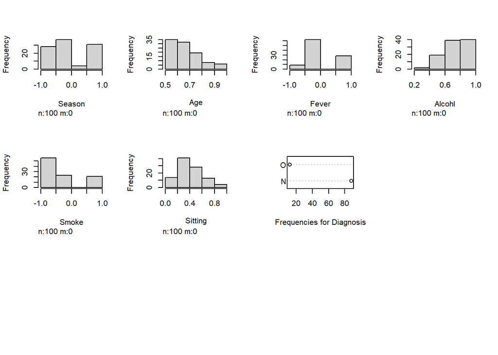

```r
hist.data.frame(dataproj)
```

*Our data base has mostly categorical datasets with values ranging from 0 to 1, using as.numeric we are changing the categorical char values to numeric*

```r
#factors are represented in R as integres with the first factor as 1
#to change use -1
dataproj$Diagnosis <- as.numeric(as.factor(dataproj$Diagnosis))-1
```

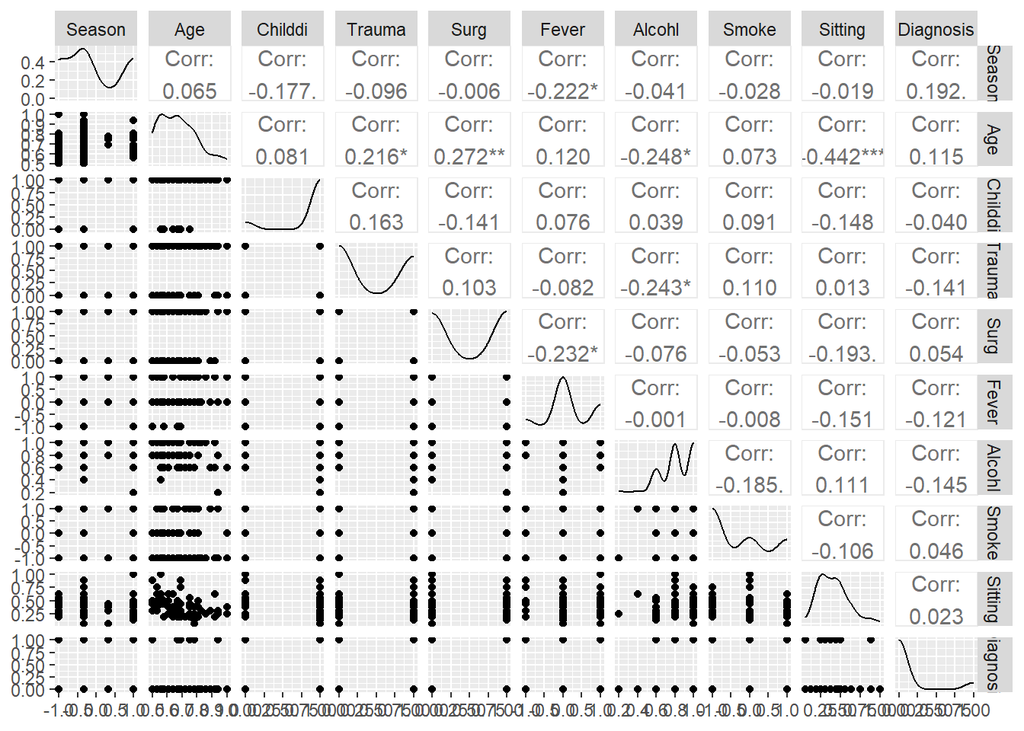

```r
#install.packages("ggplot2")
#install.packages("GGally")
library("ggplot2")
library("GGally")
ggpairs(dataproj)
```

*Hpythesis Testing*

[output not shown]

*We can see the data is not highly correlated hence there is a low chance of adding predictor variables inn the regression* *Creating a logistic regression model using the glm function*

```r
library("caTools")
set.seed(1)
sample <- sample.split(dataproj$Diagnosis, SplitRatio = 0.7)
traindata <- subset(dataproj, sample == TRUE)
testdata <- subset(dataproj, sample == FALSE)
model = glm(Diagnosis~ Age+Alcohl+Smoke+Sitting,data = traindata,family = "binomial")
summary(model)
```

```
##
## Call:
## glm(formula = Diagnosis ~ Age + Alcohl + Smoke + Sitting, family = "binomial",
##     data = traindata)
##
## Deviance Residuals:
##     Min       1Q   Median       3Q      Max
## -0.9458  -0.5000  -0.4234  -0.3260   2.3014
##
## Coefficients:
##             Estimate Std. Error z value Pr(>|z|)
## (Intercept)  -5.5955     3.4783  -1.609    0.108
## Age           4.5757     3.2754   1.397    0.162
## Alcohl       -0.9791     2.0762  -0.472    0.637
## Smoke         0.1056     0.4687   0.225    0.822
## Sitting       3.0102     2.2474   1.339    0.180
##
## (Dispersion parameter for binomial family taken to be 1)
##
##     Null deviance: 49.754  on 69  degrees of freedom
## Residual deviance: 46.645  on 65  degrees of freedom
## AIC: 56.645
##
## Number of Fisher Scoring iterations: 5
```

```r
#(model)
```

*From the summary we can see that Age, Alcohl, Smoking and Sitting is not significant attribute in prediction of Diagnosis*

[output not shown]

*To find out which attributes are aactually having an effect on the Diagnosis*

```r
model2 = glm(Diagnosis~.,data = traindata,family = "binomial")
summary(model2)
```

```
##
## Call:
## glm(formula = Diagnosis ~ ., family = "binomial", data = traindata)
##
## Deviance Residuals:
##     Min       1Q   Median       3Q      Max
## -1.3897  -0.3971  -0.2458  -0.1033   2.7575
##
## Coefficients:
##             Estimate Std. Error z value Pr(>|z|)
## (Intercept) -8.07107    5.27948  -1.529   0.1263
## Season       0.44508    0.61422   0.725   0.4687
## Age          8.18190    4.97772   1.644   0.1002
## Childdi      0.90306    1.33211   0.678   0.4978
## Trauma      -2.41735    1.17267  -2.061   0.0393 *
## Surg         0.69599    0.94891   0.733   0.4633
## Fever       -2.02764    0.94364  -2.149   0.0317 *
## Alcohl      -2.71060    2.68479  -1.010   0.3127
## Smoke        0.07967    0.56940   0.140   0.8887
## Sitting      5.43837    3.20045   1.699   0.0893 .
## ---
## Signif. codes:  0 '***' 0.001 '**' 0.01 '*' 0.05 '.' 0.1 ' ' 1
##
## (Dispersion parameter for binomial family taken to be 1)
##
##     Null deviance: 49.754  on 69  degrees of freedom
## Residual deviance: 34.311  on 60  degrees of freedom
## AIC: 54.311
##
## Number of Fisher Scoring iterations: 6
```

*From this we can see that Trauma and Fever are two significant factor in the diagnosis.*

```r
anova(model, test = "Chisq")
```

```
## Analysis of Deviance Table
##
## Model: binomial, link: logit
##
## Response: Diagnosis
##
## Terms added sequentially (first to last)
##
##
##         Df Deviance Resid. Df Resid. Dev Pr(>Chi)
## NULL                       69     49.754
## Age      1  1.05314        68     48.700   0.3048
## Alcohl   1  0.24026        67     48.460   0.6240
## Smoke    1  0.04324        66     48.417   0.8353
## Sitting  1  1.77170        65     46.645   0.1832
```

*Now we can try to predict the values using the test data*

```r
predictmodel <- predict(object = model,  type = "response", newdata = testdata)
head(predictmodel)
```

```
##          6          8          9         17         21         22
## 0.14087298 0.36144425 0.05713607 0.06862570 0.06499650 0.11933762
```

```r
#Normalizing the output
modelpred<-ifelse(predictmodel>0.5,1,0)
matrixconf <- table(testdata[,10],modelpred)

accuracymodel <- matrixconf[1,1]/sum(matrixconf)
accuracymodel
```

```
## [1] 0.8666667
```